# Day 16

Author

Kasia Kedzierska

Published

December 16, 2024

Modified

December 17, 2024

Today we are spectators to the Reindeer Olympics – specifically the Reindeer Maze. Check out the full back story and problem setup on the official [Day 16 of Advent of Code 2024](https://adventofcode.com/2024/day/16) website.

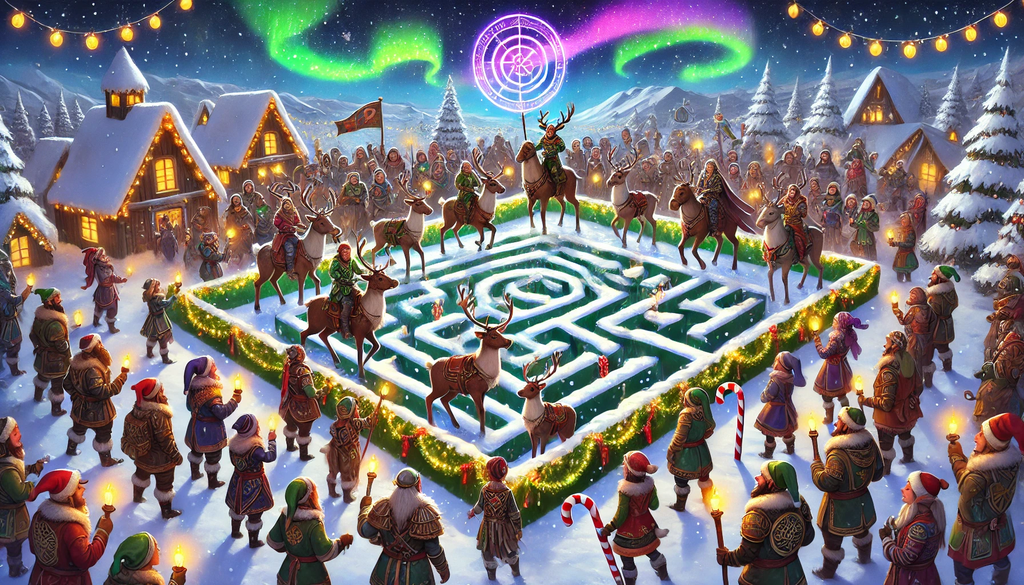

**Setting up**

```python
from misc.helper import verify_answer

example_input_file_1 = "../inputs/example_day_16_1.txt"
example_input_file_2 = "../inputs/example_day_16_2.txt"
input_file = "../inputs/day_16.txt"
```

## Part 1: Cheapest path

In this task, we are given a maze and need to determine the *cheapest path* from the start (`S`) to the end (`E`). The maze is a grid where every movement has an associated cost.

### Movement Rules:

1. **Starting Point**: We begin at `S`, facing **East**.
2. **Moving Forward**: A step in the current direction costs **1**.
3. **Turning**: Changing direction either **clockwise** or **counterclockwise** costs **1000**.
4. **Walls**: Movement into walls is **not allowed**.

The objective is to find the path from `S` to `E` with the **minimum cost**.

### Example Maze

Consider the following grid:

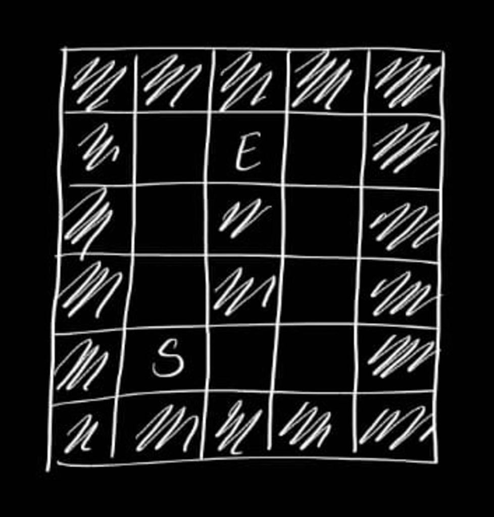

### Example Solution

There are two possible paths from `S` to `E`:

1. The first path involves **2 rotations** and **6 steps**, resulting in a total cost of **2006**.
2. The second path involves **2 rotations** and **4 steps**, resulting in a total cost of **2004**.

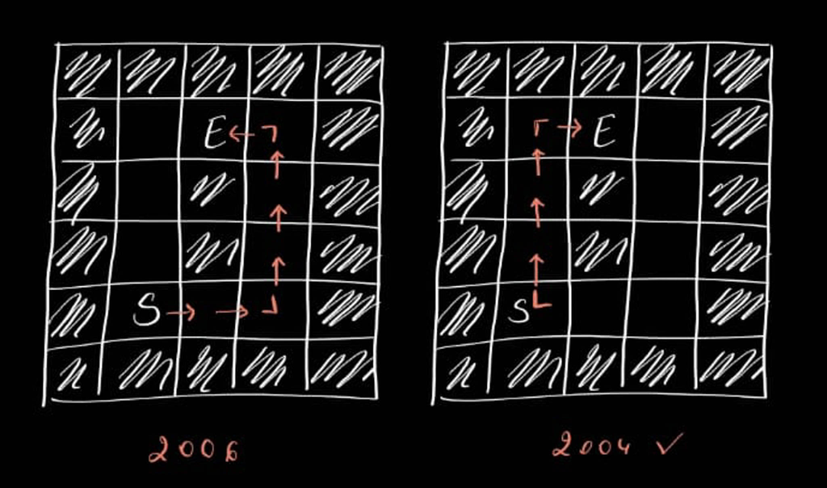

Thus, the **cheapest path** has a cost of **2004**.

First, let’s parse the input data and represent the maze as an array.

```python
import numpy as np

simple_grid = """
#####
#.E.#
#.#.#
#.#.#
#S..#
#####
"""


def parse_input(grid):
    grid = grid.strip().split("\n")
    grid_mat = np.zeros((len(grid), len(grid[0])))
    for i, row in enumerate(grid):
        for j, cell in enumerate(row):
            if cell == "S":
                start = (i, j)
            elif cell == "E":
                end = (i, j)
            grid_mat[i, j] = 1 if cell == "#" else 0
    return grid_mat, start, end


parse_input(simple_grid)
```

```
(array([[1., 1., 1., 1., 1.],
        [1., 0., 0., 0., 1.],
        [1., 0., 1., 0., 1.],
        [1., 0., 1., 0., 1.],
        [1., 0., 0., 0., 1.],
        [1., 1., 1., 1., 1.]]),
 (4, 1),
 (1, 2))
```

Next, I will use the Dijkstra’s algorithm to find the cheapest path from `S` to `E`. I will leverage `heapq` to implement the priority queue required for Dijkstra’s algorithm.

```python
import heapq


def find_cheapest_path(grid, start, end, initial_dir=(0, 1)):
    n, m = grid.shape
    clockwise = np.array([[0, 1], [-1, 0]])
    counterclockwise = np.array([[0, -1], [1, 0]])

    # priority queue: (cost, (i, j), direction)
    pq = []
    heapq.heappush(pq, (0, start, np.array(initial_dir)))

    # make note of visited cells
    visited = set()

    while pq:
        cost, (i, j), dir = heapq.heappop(pq)

        # if at the end, return the cost
        if (i, j) == end:
            return cost

        visited.add((i, j, tuple(dir)))

        # forward
        new_i, new_j = i + dir[0], j + dir[1]
        if 0 <= new_i < n and 0 <= new_j < m and grid[new_i, new_j] != 1:
            if (new_i, new_j, tuple(dir)) not in visited:
                heapq.heappush(pq, (cost + 1, (new_i, new_j), tuple(dir)))

        for new_dir in [clockwise @ dir, counterclockwise @ dir]:
            new_i, new_j = i + new_dir[0], j + new_dir[1]
            if 0 <= new_i < n and 0 <= new_j < m and grid[new_i, new_j] != 1:
                if (new_i, new_j, tuple(new_dir)) not in visited:
                    heapq.heappush(
                        pq, (cost + 1001, (new_i, new_j), tuple(new_dir))
                    )
    return -1  # no path found
```

Finally, I will assemble the functions into `part_one` to solve the problem.

```python
from pathlib import Path


def part_one(input: str) -> int:
    if Path(input).is_file():
        with open(input, "r") as f:
            grid = f.read()
    else:
        grid = input

    return find_cheapest_path(*parse_input(grid))
```

I will test the solution on the example above and the ones provided in the problem statement.

```python
verify_answer(part_one, simple_grid, 2004)
```

```
✔️ That's right! The answer is 2004.
```

```python
verify_answer(part_one, example_input_file_1, 7036)
```

```
✔️ That's right! The answer is 7036.
```

```python
verify_answer(part_one, example_input_file_2, 11048)
```

```
✔️ That's right! The answer is 11048.
```

Since the solutions are correct, I will proceed to solve the actual problem.

```python
%time part_one(input_file)
```

```
CPU times: user 1.13 s, sys: 7.71 ms, total: 1.14 s
Wall time: 1.17 s
```

```
102488
```

> That’s the right answer! You are one gold star ⭐ closer to finding the Chief Historian.

## Part 2: All visited cells

In this part, we need to count the number of cells visited by while walking from `S` to `E` using any of the cheapest path. In the example case, we would count **5** cells.

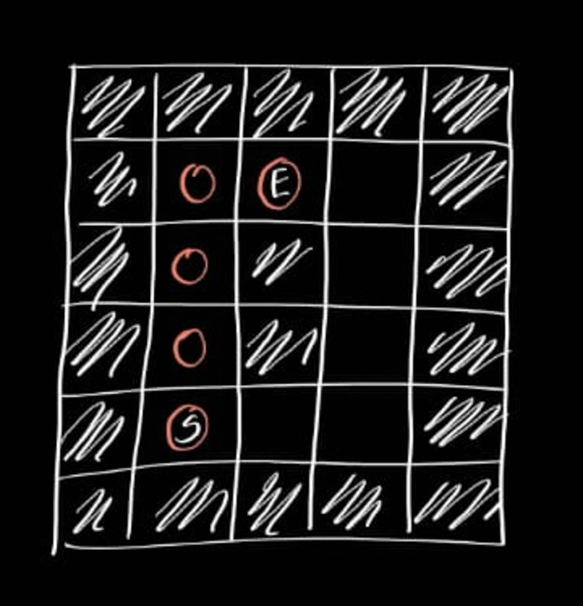

This time, I will modify the solution to include noting all paths that have the same minimum cost. I will then create a set of all visited cells and return the count.

```python
def find_cheapest_path_with_visited(grid, start, end, initial_dir=(0, 1)):
    n, m = grid.shape
    clockwise = np.array([[0, 1], [-1, 0]])
    counterclockwise = np.array([[0, -1], [1, 0]])

    # priority queue: (cost, (i, j), direction as tuple, path)
    pq = []
    heapq.heappush(pq, (0, start, tuple(initial_dir), [start]))

    # dictionary to store visited states
    visited = {}

    # store all paths with the cheapest cost
    all_paths = []
    cheapest_cost = None

    while pq:
        cost, (i, j), dir, path = heapq.heappop(pq)

        state = (i, j, dir)

        # if already visited, skip if this path is more expensive
        if state in visited:
            if cost > visited[state]:
                continue
        visited[state] = cost

        # if at the end, store the path
        if (i, j) == end:
            if cheapest_cost is None:
                cheapest_cost = cost
            if cost == cheapest_cost:
                all_paths.append(path)
            continue

        # move forward
        new_i, new_j = i + dir[0], j + dir[1]
        if 0 <= new_i < n and 0 <= new_j < m and grid[new_i, new_j] != 1:
            heapq.heappush(
                pq, (cost + 1, (new_i, new_j), dir, path + [(new_i, new_j)])
            )

        for turn in [clockwise, counterclockwise]:
            new_dir = turn @ np.array(dir)
            new_i, new_j = i + new_dir[0], j + new_dir[1]
            if 0 <= new_i < n and 0 <= new_j < m and grid[new_i, new_j] != 1:
                heapq.heappush(
                    pq,
                    (
                        cost + 1001,
                        (new_i, new_j),
                        tuple(new_dir),
                        path + [(new_i, new_j)],
                    ),
                )

    return len(set(sum(all_paths, [])))
```

Now, I will assemble the functions into `part_two` to solve the problem.

```python
def part_two(input: str) -> int:
    if Path(input).is_file():
        with open(input, "r") as f:
            grid = f.read()
    else:
        grid = input

    return find_cheapest_path_with_visited(*parse_input(grid), (0, 1))
```

Couple of tests to ensure the solution is working as expected:

```python
verify_answer(part_two, example_input_file_1, 45)
```

```
✔️ That's right! The answer is 45.
```

```python
verify_answer(part_two, example_input_file_2, 64)
```

```
✔️ That's right! The answer is 64.
```

Since the tests passed, I will now run the solution on the input data.

```python
%time part_two(input_file)
```

```
CPU times: user 4.63 s, sys: 42.6 ms, total: 4.67 s
Wall time: 4.71 s
```

```
559
```

> That’s the right answer! You are one gold star ⭐ closer to finding the Chief Historian.